# lab3

```python
%matplotlib inline
import numpy as np
import matplotlib
import matplotlib.pyplot as plt
import scipy
from scipy import stats

#this sets the size of the plot to something useful
plt.rcParams["figure.figsize"] = (20, 15)
```

1. A) 1: In the graph of data, I draw a pdf of Gaussian distribution trying to fit the background distribution, and isolate the noises. And then we can see most of the histogram fit the Gaussian distribution shape, expect the very left corner of the porabola, and we can also see obvious and discrete points at around 0, 2, 16, 23 that are supposed to be the noise.

2: The statistical question of this plot should be: what is the probability to find a signal of noise in the background temperature readings.

3: In the noise free data, a Gaussian distribution of the background data is expected. We can use a Gaussian distribution with a mean of 12 and scale of 0.4, and use cdf to find the probabilities to get points at (0, 2, 16, 23). The sigma of each point are 4.906713927147908e-198, 3.056696706382561e-138, 7.61985302416047e-24, and 8.77817055687808e-167, which are all way below 5-sigma i.e. 2.85714286e-7. Then the data except in the range of 10 to 14 can be considered not signal-like.

C) There are 3 commissions made.They are inavoidable but we can reduce the amount of commission by decreasing the degrees of precision.

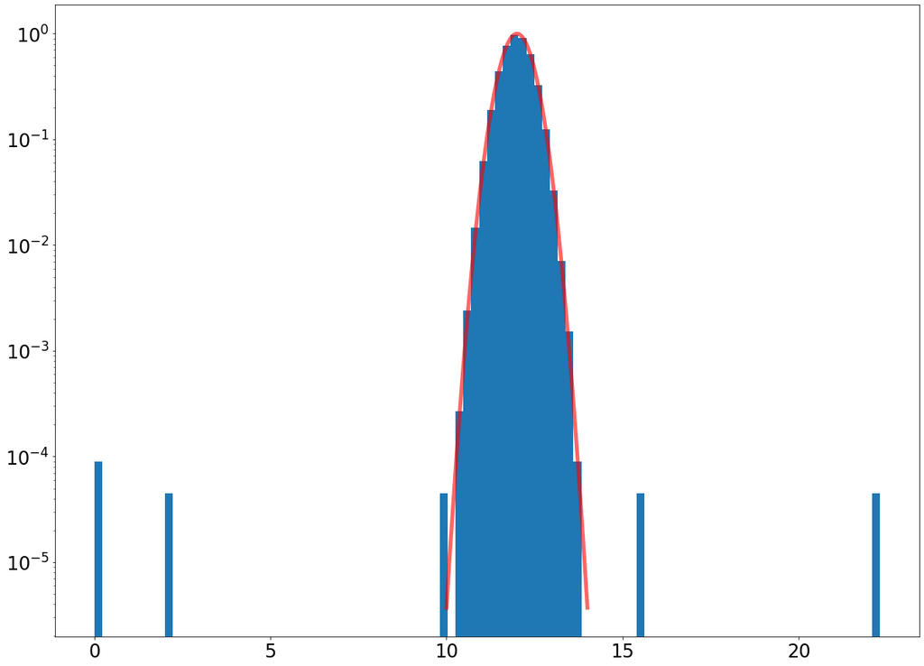

```python
d = np.append(stats.norm.rvs(loc = 12., scale = 0.4, size = 100000), [10., 10.3, 2.1, 0., 0., 15.6, 22.3, 12.7])
x = np.linspace(10, 14, 100000)
fig, ax = plt.subplots(1, 1)
ax.hist(d,100, density=True)
ax.plot(x, stats.norm.pdf(x, loc = 12, scale = 0.4), 'r', lw=5, alpha=0.6)
#x = np.linspace(4.95,5.05,1000)
#ax.plot(x,stats.norm.pdf(x,loc = 5., scale = 0.01),linewidth = 8,alpha = 0.7)
plt.tick_params(labelsize = 24)
plt.yscale('log')
plt.show()
```

```python
a = 0
b = 2
c = 16
d = 23
sigma_a = stats.norm.cdf(a, loc=12, scale=0.4)
sigma_b = stats.norm.cdf(b, loc=12, scale=0.4)
sigma_c = stats.norm.sf(c, loc=12, scale=0.4)
sigma_d = stats.norm.sf(d, loc=12, scale=0.4)
print(sigma_a)
print(sigma_b)
print(sigma_c)
print(sigma_d)
```

```
4.906713927147908e-198
3.056696706382561e-138
7.61985302416047e-24
8.77817055687808e-167
```

2. 1) Finding the 5-sigma detection of movement can indicate the significance of the data presenting more as a stationary point of source if the 5-sigma detection of movement is low enough.

2) The pdf of the graph is the output of OR function of two 2D Gaussian distributions with very close values of mean.

3) 5 arcseconds is just corresponding to 5 sigma.

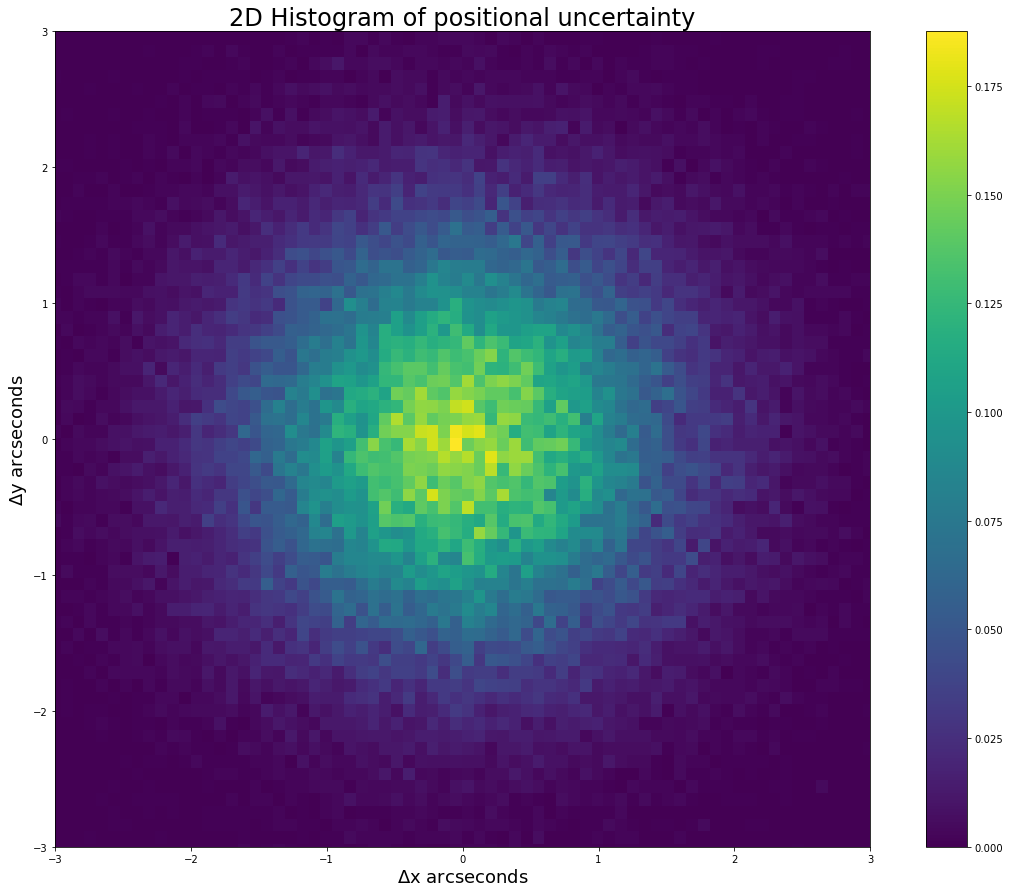

```python
a = np.vstack((stats.norm.rvs( scale = 1, size = 100000), stats.norm.rvs( scale = 1, size = 100000)))
a.shape
fig, ax = plt.subplots(1, 1)
h = ax.hist2d(a[0,:],a[1,:],bins=100, density=True);
ax.set_aspect('equal', 'box')
plt.xlim([-3 , 3])
plt.ylim([-3 , 3])
plt.title("2D Histogram of positional uncertainty", fontsize = 24)
plt.ylabel("$\Delta$y arcseconds", fontsize = 18)
plt.xlabel("$\Delta$x arcseconds", fontsize = 18)
plt.colorbar(h[3], ax=ax)
```

3. 1) In intervals each minute for 7200 trials, if we have 6800 cosmic rays detected, what is the probability that cosmic rays were actually blocked by the shadow of sun or moon?

2) The background pdf of cosmic rays detection in all trials is expected to be Gaussian with a mean of 7200. The integral to do is from positive infinity of 6800 of get the probability of occurance of shadow, because if there are more cosmic rays found, there is less probability of a shadow appearing.

3) The sigma should be the probability getting a 6800 divided by trials factor of 7200.